# gSMS Calibration Analysis

Sophia Becker

2024-01-31

Throughout, bolded figure labels correspond to figures in the paper, “Field testing of gamma-ray spectroscopy method for soil water content estimation in an agricultural field”. Required csv files for this code are located in the folder, “CsvFiles”.

## Parameter set up

```r
# Parameters
mu.g <- 0.05257 # mass attentuation coefficient of soil (silica) cm^2/g
mu.w <- 0.05835 # mass attentuation coefficient of water cm^2/g

bweslope <- -0.012 # Baldoncini et al., 2019

minIo <- max(timeseries$K40)
maxIo <- 1.5*minIo
min.mu.g <- mu.g/2
max.mu.g <- 2* mu.g
minBWEslope <- -0.5
maxBWEslope <- 0

# preliminary solve for Io using the two bare soil gravimetric samples

Io <- (SampledfBare$DepthWtWtot*(mu.w/mu.g)+1)*SampledfBare$K

avgIo <- mean(Io)

# simplified data frame for fitting model parameters
data <- data.frame(It = Sampledf$K, BWE = Sampledf$TotBWE, y = Sampledf$DepthWtWtot)

write.csv(data, file = paste0(outDir, "\\TotalWaterDataframe", stamp,".csv"))
```

## Calibration Equation

The calibration equation tested is:

$$\theta_{tot} = (\frac
{I_{0}*f(BWE)}{I_{t}}-1)* \frac {(\frac {\mu}{\rho})_{s}}{(\frac
{\mu}{\rho})_{w}}$$

where
$$f(BWE)= b*BWE + 1.$$
$BWE$ is biomass water equivalence in mm and $b$ is the slope of the biomass water correction factor. The biomass correction factor , $f(BWE)$, is from [Baldoncini et al., 2019](https://doi.org/10.1016/j.geoderma.2018.08.012).

$\theta_{tot}$ is the total water content in $g$ $g^{-1}$(sum of gravimetric pore water, lattice water, and SOC water), $I_{0}$ is the K-40 concentration in dry soil, $I_{t}$ is the K-40 concentration at measurement time, $(\frac {\mu}{\rho})_{s}$ is the mass attenuation coefficient of the soil ($cm^2 g^{-1}$), and $(\frac {\mu}{\rho})_{w}$ is the mass attenuation coefficient of water ($cm^2 g^{-1}$).The equation is coded below:

```r
calEq <- function(It, BWE, b = bweslope, Io, mg, mw = mu.w)
  (((((Io *(b*BWE+1))/It)-1)*mg/mw))
```

## Fitting Calibration Equation

The main calibration equations under consideration are Eq. 1 and Eq. 2, but Eq. 1b and 2b are also included in the code. Eq. 1b and Eq. 2b fit the slope of the biomass correction factor for comparison with the value from Baldoncini et al., 2019.

**Table 1.** Calibration equations and the parameters fit within each.

|  | Io | a | BWE correction factor slope |
| --- | --- | --- | --- |
| Eq. 0 | Yes | NA | NA |
| Eq. 1 | Yes | NA | No |
| Eq. 1b | Yes | NA | Yes |
| Eq. 2 | Yes | Yes | No |
| Eq. 2b | Yes | Yes | Yes |

The function, [sceua](https://rdrr.io/rforge/rtop/man/sceua.html) (within the rtop package) uses the shuffled complex evolution algorithm for robust and simultaneous parameter estimation. Below is an example of how the sceua function is used.

```r
# write calibration function in terms of parameter vector

#Independent variables are x1 and x2.
# x1 = It
# x2 = BWE
# Parameters to be fit are contained in the vector, pars
# pars  = c(Io, mu.g, bweslope)

CalEq <- function(x1, x2, pars)
  (((((pars[1] *(pars[3]*x2+1))/x1)-1)*pars[2]/mu.w))

# write objective function, sum of absolute value of residuals
OFUN <- function(pars, x1, x2, yobs){
  yvals = CalEq(x1, x2, pars)
  sum(abs(yvals-yobs))
}

# use sceua function to find all three parameters

sceuares <- sceua(OFUN, pars = c(avgIo, mu.g, bweslope), lower = c(minIo, min.mu.g, minBWEslope),
                  upper = c(maxIo, max.mu.g, maxBWEslope),
                  x1 = data$It, x2 = data$BWE, yobs = data$y)
```

The parameters found are 903.34, 0.03,and -0.01 for $I_{0}$, $(\frac {\mu}{\rho})_{s}$, and $b$, respectively.

## First, evaluate the most basic calibration equation

“Equation 0” fits $I_{0}$ without a biomass correction factor and uses the 1.46 MeV $SiO_{2}$ literature value for$(\frac {\mu}{\rho})_{s}/(\frac {\mu}{\rho})_{w}$. Below is an example of the code that was used to fit parameters for each of the models in Table 1. The summary statistics are calculated from the squared error for each of the 27 leave-one-out cross-validation test values.

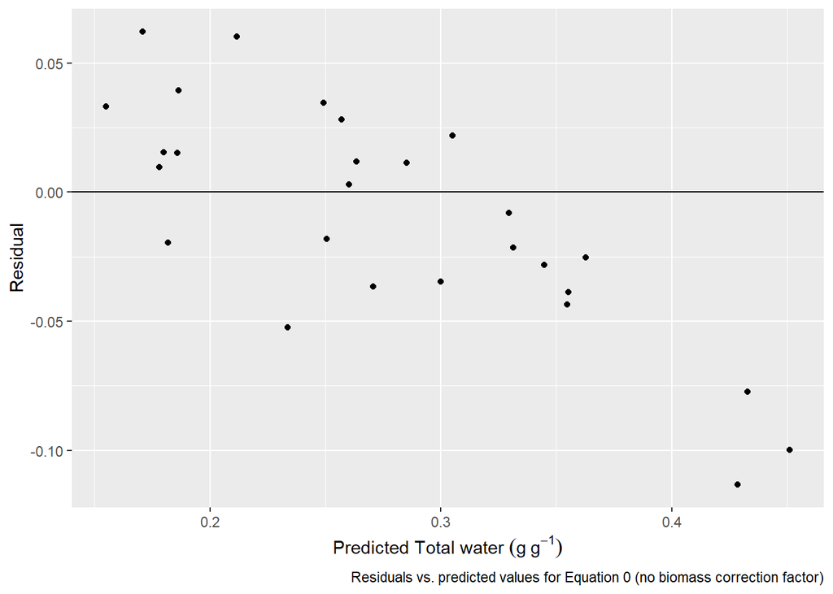

```r
# do LOOCV for calEqfit0 (fitting Io with no biomass correction factor)

# write calibration function in terms of parameter vector

# x1 = It
# x2 = BWE
# pars  = c(Io)

CalEq_0 <- function(x1, x2, pars)
  (((((pars[1] *((0*x2)+1))/x1)-1)*mu.g/mu.w))

# write objective function, sum of absolute value of residuals
OFUN <- function(pars, x1, x2, yobs){
  yvals = CalEq_0(x1, x2, pars)
  sum(abs(yvals-yobs))
}

num.obs <- nrow(data)-1 # number of observations used in each of the LOOCV predictions
num.pred <- 2 # number of variables + fit parameters

Model0_LOOCV <- data.frame(matrix(ncol = 4, nrow = nrow(data)))
colnames(Model0_LOOCV)<- c("SqErr for Test value", "Io", "mu_g", "BWE slope")

# use a for loop to perform leave-one-out cross-validation
# in each iteration, all but one sample is used to fit the equation with sceua, and
# then the fitted parameters are used to predict the water content of the left-out sample

set.seed(3)

for (i in 1:nrow(data)){
  # use sceua function to find all three parameters
  sceuares <- sceua(OFUN, pars = c(avgIo), lower = c(minIo),
                  upper = c(maxIo),
                  x1 = data$It[-i], x2 = data$BWE[-i], yobs = data$y[-i])

  pred1 <- CalEq_0(x1 = data$It[i], x2 = data$BWE[i], pars = sceuares$par)
  resid <- pred1 - data$y[i]
  sqerr <- resid^2

  results <- data.frame(SqErr = sqerr, Io = sceuares$par[1], mu_g = mu.g, BWEslope = 0)
  Model0_LOOCV[i,]<- results
}

# calculate summary statistics

rmse <- sqrt(mean(Model0_LOOCV[,1])) # df column of squared errors/residuals
SSE <- sum(Model0_LOOCV[,1])
SStot <- sum((data$y - mean(data$y))^2)
rsq <- 1-SSE/SStot
adj.rsq <- 1- ((1-rsq)*(num.obs-1)/(num.obs-num.pred-1))
LOOCV.sum.stats0 <- data.frame(RMSE = rmse, Rsq = rsq, AdjRsq = adj.rsq,
                               Io = mean(Model0_LOOCV$Io),
                               BWE_slope = "NA", a = "NA")

pred0 <- CalEq_0(x1 = data$It, x2 = data$BWE, pars= c(Model0_LOOCV$Io))

resid0 <- data$y - pred0 # observed - predicted

Predresid0 <- ggplot()+
  geom_point(aes(x = pred0, y = resid0))+
  geom_hline(yintercept = 0)+
  labs(x = bquote('Predicted Total water ' (g ~g^-1)), y = "Residual",
       caption = "Residuals vs. predicted values for Equation 0 (no biomass correction factor)")

Predresid0
```

[figure not shown]

Summary statistics and average fit parameters from LOOCV for Model 0.

| RMSE | Rsq | AdjRsq | Io | BWE_slope | a |
| --- | --- | --- | --- | --- | --- |
| 0.052 | 0.127 | 0.051 | 783.371 | NA | NA |

[figure not shown]

```r
# find the linear relationship between the residuals and K40

# K40
newk40 <- seq(500, 700, 1)
Klm <- lm(resid0 ~ K, data = Sampledf)
summKlm <- summary(Klm)
resKpred <- predict.lm(Klm, newdata = data.frame(K = newk40))

Kresid0rgr <- ggplot()+
  geom_point(aes(x = Sampledf$K,y = resid0))+
  geom_line(aes(y = resKpred, x = newk40), color = "red")+
  geom_hline(yintercept = 0)+
  ylim(c(-0.12, 0.12))+
  xlim(c(520, 680))+
  labs(x = NULL, y = bquote('Residual ' (g ~g^-1)), caption = "Residuals vs. K-40 for Equation 0 (no biomass correction factor)")

Kresid0rgr
```

**Figure 3.** The experimental relationship between total water and K-40 compared to the relationship predicted by Eq. 0 (black line) and the corresponding 95% confidence interval.

## Next, Evaluate Calibration Equation 1

The calibration equation is $\theta_{tot} = (\frac {I_{0}*f(BWE)}{I_{t}}-1)* \frac {(\frac {\mu}{\rho})_{s}}{(\frac {\mu}{\rho})_{w}}.$ Calibration Eq. 1 uses the BWE correction factor and mass attenuation coefficients from the literature to fit $I_{0}$ parameter in the calibration equation, using the 27 observations.

Summary statistics and average fit parameters from LOOCV for calibration Eq. 1.

| RMSE | Rsq | AdjRsq | Io | BWE_slope | a |
| --- | --- | --- | --- | --- | --- |
| 0.045 | 0.344 | 0.254 | 792.394 | -0.012 | NA |

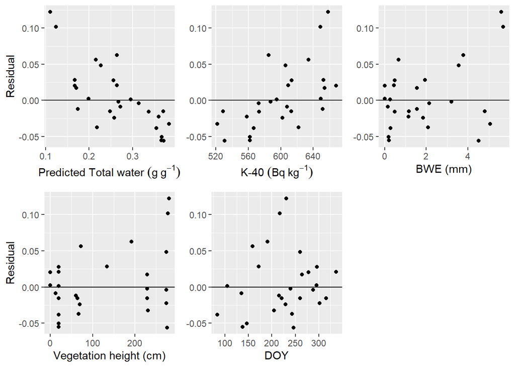

Residuals of Eq. 1 compared to predicted total water, K-40, biomass water equivalence (BWE), vegetation height, and day of year (DOY).

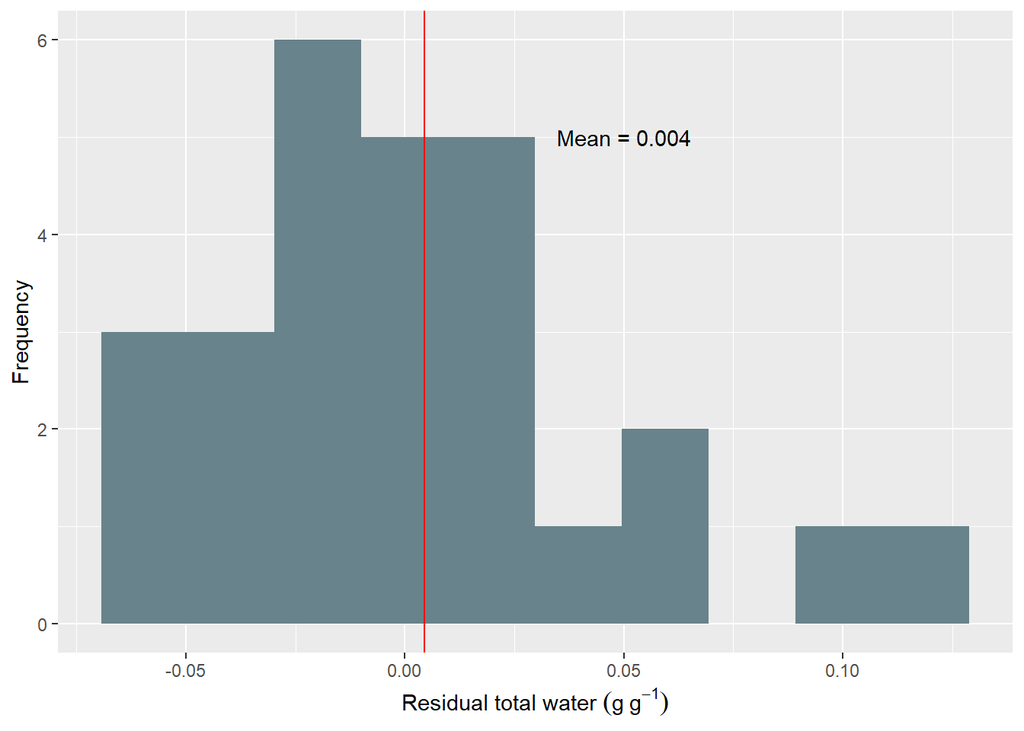

Distribution of Eq. 1 residuals, with mean shown by red vertical line.

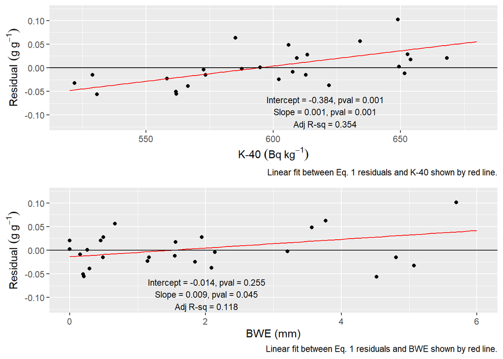

## Evaluate Calibrationi Equation 1b

Calibration Equation 1, $\theta_{tot} = (\frac {I_{0}*f(BWE)}{I_{t}}-1)* \frac {(\frac {\mu}{\rho})_{s}}{(\frac {\mu}{\rho})_{w}}$, is used to fit $I_{0}$ and the slope for the biomass correction factor to the data simultaneously.

Summary statistics and average fit parameters from LOOCV for Eq. 1b.

| RMSE | Rsq | AdjRsq | Io | BWE_slope | a |
| --- | --- | --- | --- | --- | --- |
| 0.0485 | 0.249 | 0.106 | 785.636 | -0.0104 | NA |

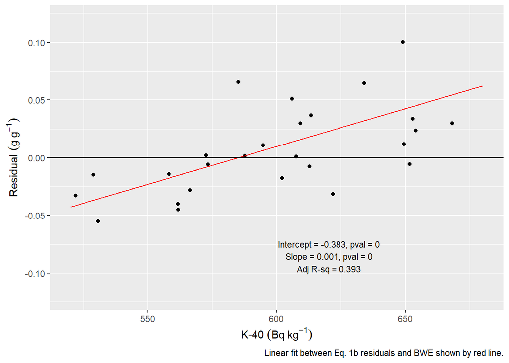

## Evaluate Calibration Equation 2

The calibration equation is
$$\theta_{tot}
= (\frac {I_{0}*f(BWE)}{I_{t}}-1)* \frac {(\frac
{\mu}{\rho})_{s}}{(\frac {\mu}{\rho})_{w}}*a.$$
In Calibration Eq. 2, $I_{0}$ and $a$, the correction factor parameter for the ratio between the soil and water mass attenuation coefficients, are fit simultaneously.

Summary statistics and average fit parameters from LOOCV for Calibration Equation 2.

| RMSE | Rsq | AdjRsq | Io | BWE_slope | a |
| --- | --- | --- | --- | --- | --- |
| 0.0327 | 0.6588 | 0.5938 | 896.7397 | -0.012 | 0.6326 |

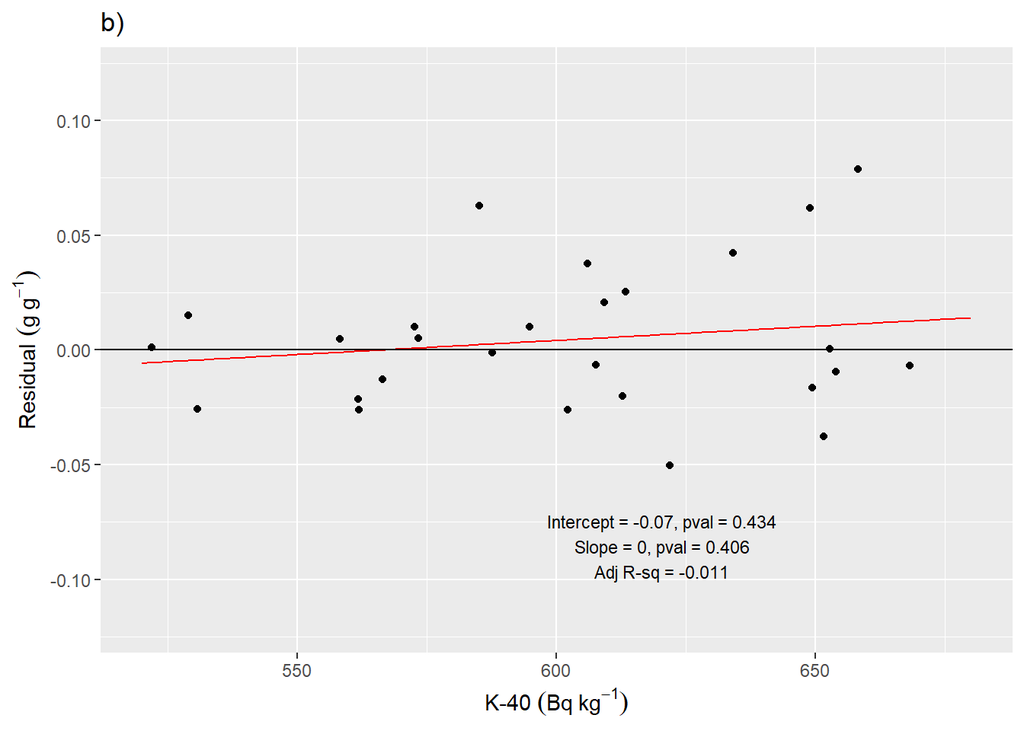

## Evaluate Calibration Equation 2b

The calibration equation is
$$\theta_{tot}
= (\frac {I_{0}*f(BWE)}{I_{t}}-1)* \frac {(\frac
{\mu}{\rho})_{s}}{(\frac {\mu}{\rho})_{w}}*a.$$
In Calibration Eq. 2b, $I_{0}$ and the correction factor parameter for the ratio between the soil and water mass attenuation coefficients, $a$, are fit simultaneously, along with the slope of the biomass correction factor.

Summary statistics and average fit parameters from LOOCV for Eq. 2b, where Io, a, and BWE slope are fit to the data.

| RMSE | Rsq | AdjRsq | Io | BWE_slope | a |
| --- | --- | --- | --- | --- | --- |
| 0.0332 | 0.6471 | 0.5589 | 940.975 | -0.0035 | 0.5339 |

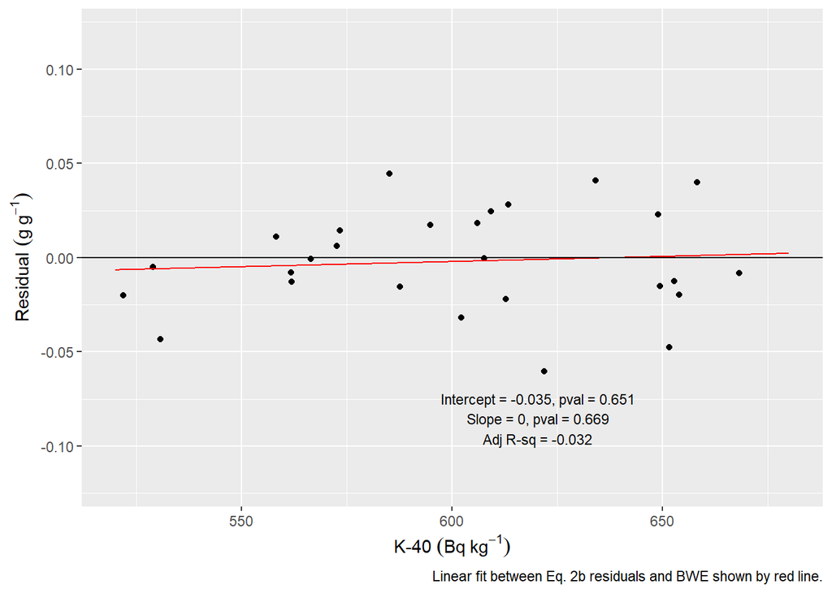

## Summary of model validations

**Table 2.** The error statistics and average parameters found for each of the calibration equation variations. Recall -0.012 is the literature value for BWE slope.

| Equation | RMSE | Rsq | AdjRsq | Io | BWE_slope | a |
| --- | --- | --- | --- | --- | --- | --- |
| 0 | 0.052 | 0.127 | 0.051 | 783.371 | NA | NA |
| 1 | 0.045 | 0.344 | 0.254 | 792.394 | -0.012 | NA |
| 1b | 0.048 | 0.249 | 0.106 | 785.636 | -0.0103805239986887 | NA |
| 2 | 0.033 | 0.659 | 0.594 | 896.740 | -0.012 | 0.632601679024572 |
| 2b | 0.033 | 0.647 | 0.559 | 940.975 | -0.00346243460765744 | 0.53389373378171 |

## 2021 Time Series figure

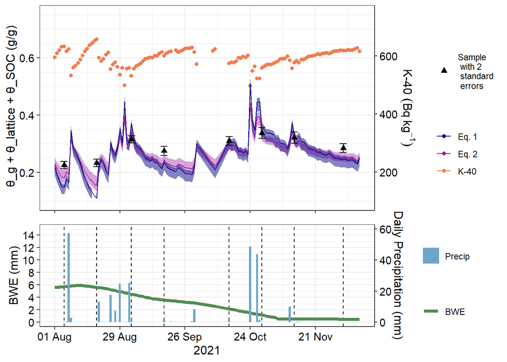

**Figure 5.** A time series summary of the 2021 sampling period. In the upper panel are the daily K-40 data, the gravimetric sample data, and the predictions from Eq. 1 and Eq. 2. with 95% confidence intervals calculated by bootstrapping. The lower panel shows precipitation events and estimated biomass water equivalence (BWE). Vertical dashed lines are the sampling dates.

## 2022 Time Series Figure

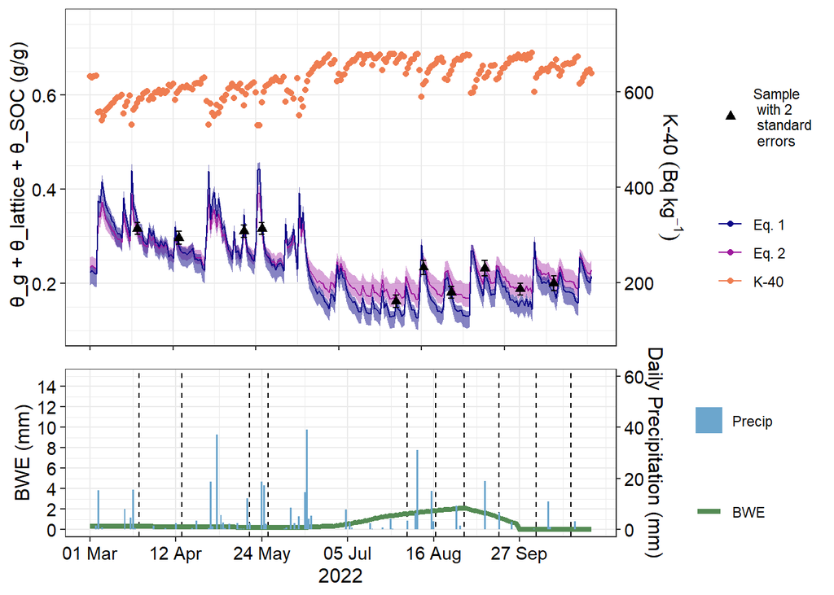

**Figure 6.** A time series summary of the 2022 sampling period. In the upper panel are the daily K-40 data, the gravimetric sample data, and the predictions from Eq. 1 and Eq. 2. with 95% confidence intervals calculated by bootstrapping. The lower panel shows precipitation events and estimated biomass water equivalence (BWE). Vertical dashed lines are the sampling dates.

## 2023 Time Series Figure

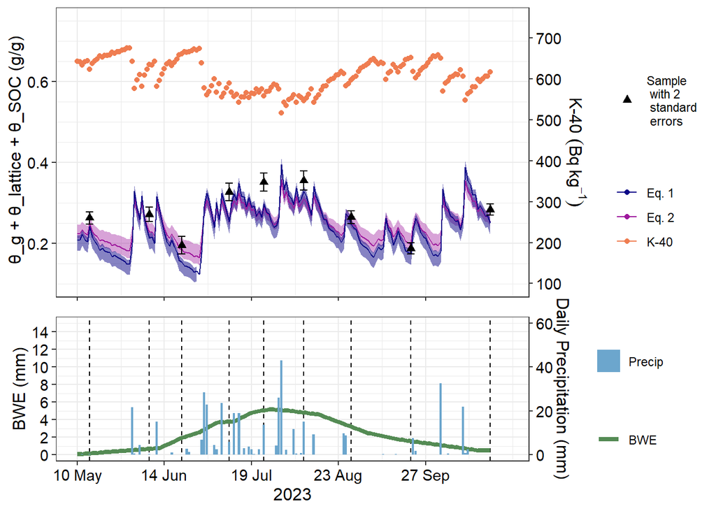

**Figure 7.** A time series summary of the 2023 sampling period. In the upper panel are the daily K-40 data, the gravimetric sample data, and the predictions from Eq. 1 and Eq. 2. with 95% confidence intervals calculated by bootstrapping. The lower panel shows precipitation events and estimated biomass water equivalence (BWE). Vertical dashed lines are the sampling dates.

## Compare Residuals for Eq. 1 and Eq. 2

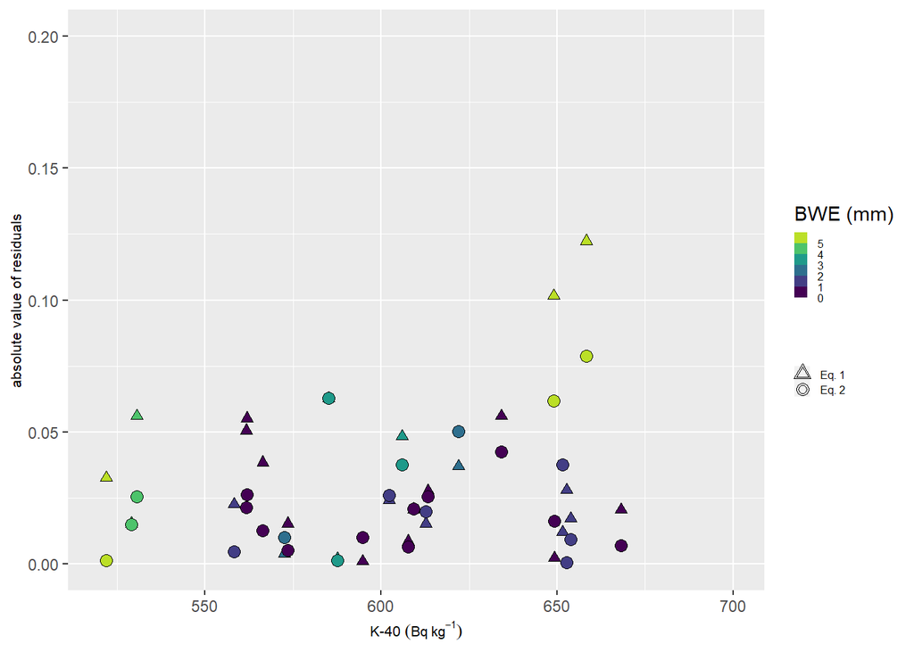

Residuals from Eq. 1 and Eq. 2 are plotted together.

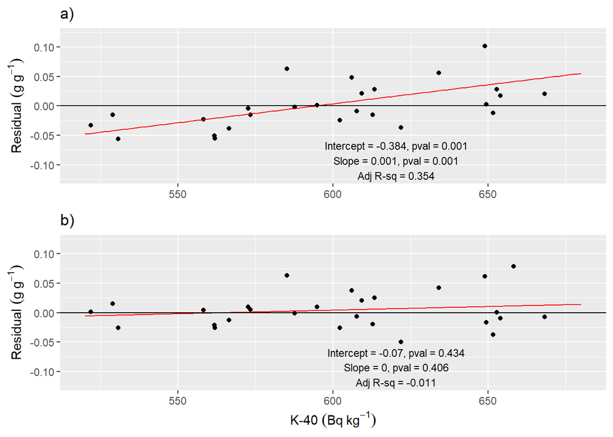

**Figure 4** a) Residuals from Eq. 1. The red line shows the significant linear trend (slope and intercept p-values < 0.01). b) Residuals from Eq. 2, where there is not a significant trend.